# TREC RAGTIME 2026

Multilingual report generation

Nidhin Pattaniyil · Tanwir Zaman · Semih Yagli — NP Labs

November 17, 2026

## What RAGTIME asks

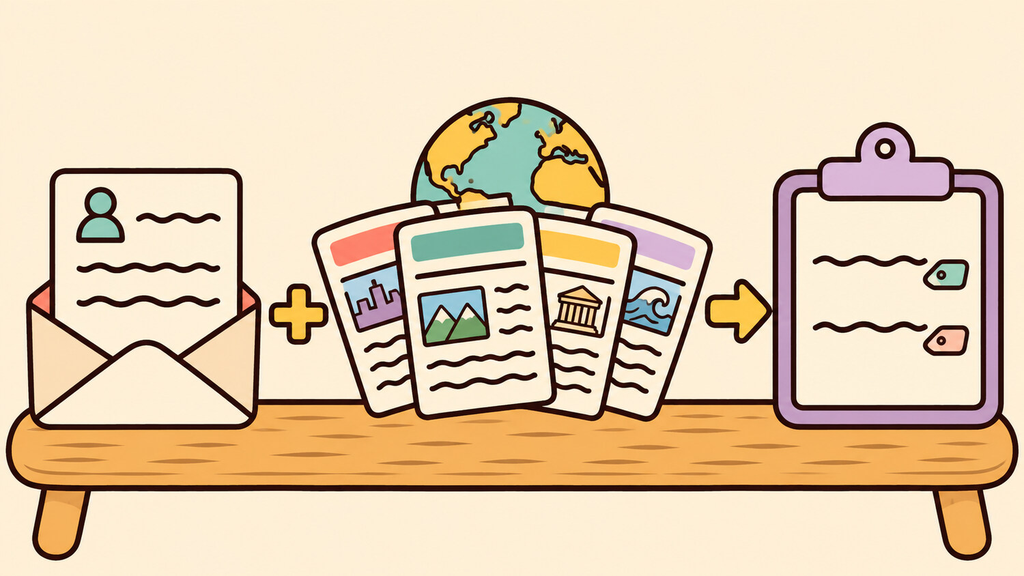

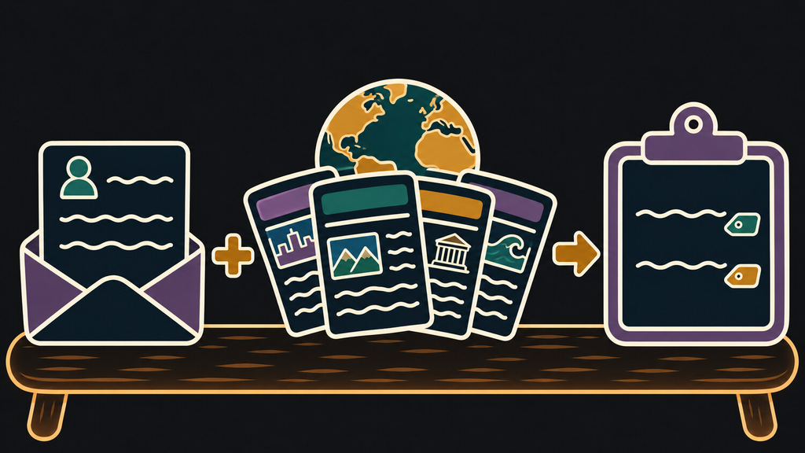

### Report request

Problem, background, character limit

### News in four languages

English · Spanish · Russian · Chinese

### English report

Citations that support each factual sentence

Next · African penguin conservation

## The request for an African penguin report

Topic 2014 · Report generation

**Problem statement**

Report on African penguin population changes, causes of decline, expert estimates of extinction risk and efforts to protect the species in South Africa and abroad.

**Requester background**

A zoo grants manager needs evidence to decide the size and focus of a multi-year conservation grant.

**Output limit**

**5,000 characters** · English sentences with citations to the original articles

[Original request fields](https://github.com/npatta01/trec_ragtime_2026/blob/a4561cf097dcfaf249ddfc3dcf25845a897d187a/topics/topics.all.2026.v0625-fix.jsonl#L15)

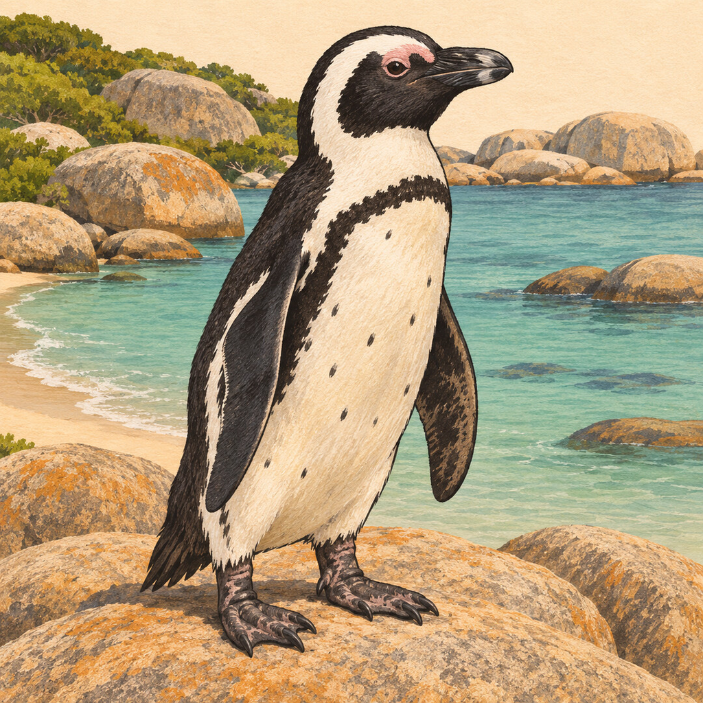

Native to the coasts of South Africa and Namibia. [Species profile](https://www.aquarium.co.za/foundation/animals/african-penguin)

## Retrieval

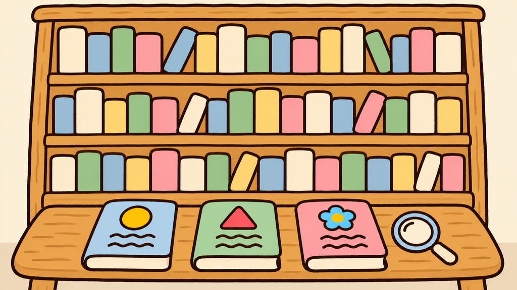

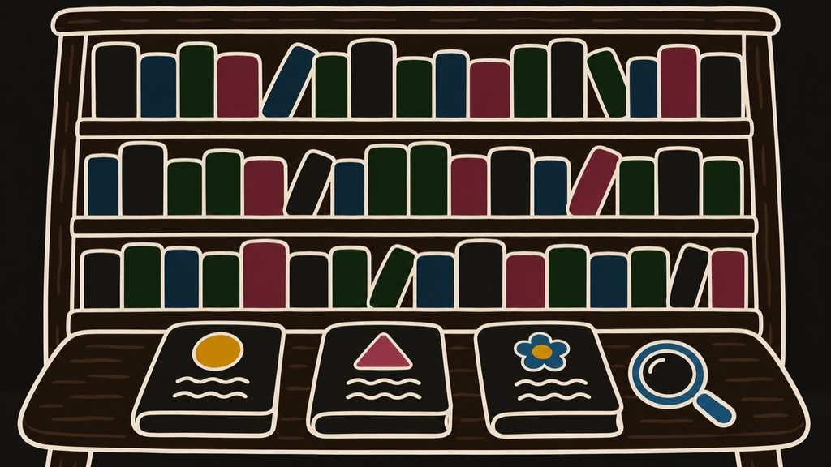

1. Plan queries
2. Search and load English text

## How DeepSeek split the penguin request

**Problem statement**  
+ requester background

→

[figure not shown]

**DeepSeek V4 Flash**

→

Generated queries

**1** broad + **7** focused

**q₀** Broad rewrite**

`African penguin population decline causes conservation measures South Africa international protection extinction risk`

**q₄** South African measures**

`South Africa African penguin conservation actions marine protected areas breeding sites`

**q₇** Fishing restrictions**

`African penguin conservation measures government regulations fishing restrictions`

Keep one list per query · **851 lists** across 103 requests · All eight penguin queries

## English queries and supplied translations

**English query**

→

Organizers’ search endpoint

### ragtime2%100

- English
- Spanish
- Russian
- Chinese

Qwen3-Embedding-8B · FAISS · RoutIR ScoreFusion  
25 hits per language · about 4M original news articles

→

Returned per query

**100 ranked document IDs**

**One Chinese search hit** `…_483118047`

→

**Load English article text**Original English or organizer-supplied `mt_docs` translation by ID

→

Reranking

**China Times on bird flu at Boulders Beach, South Africa** · Original Chinese · Supplied English machine translation

> … 28隻瀕臨絕種的企鵝有些因感染疾病死亡，有些則因染疫，難逃被撲殺命運。

> … some of the 28 endangered penguins have died from infection and others have been killed because of the disease.

[The submitted report](https://github.com/npatta01/trec_ragtime_2026/blob/a4561cf097dcfaf249ddfc3dcf25845a897d187a/submissions/np-nugget-sol-v1/NP.np-nugget-sol-v1.ragtime26.jsonl#L15) cites this Chinese original for the count of 28 penguins that died or were culled.

## Reranking

100 candidates per query

**Query + English article text**

→

[figure not shown]

Mixedbread cross-encoder

**mxbai-rerank-base-v2**

Scores the pair for relevance

→

For each query

**Sort the articles by score**

Topic 2014 · **8 × 100 = 800** query–article pairs · **601** distinct articles

Compare search and reranked positions

## Reranking the penguin articles

Topic 2014 · Two articles cited in the final report

| Article | Query | Search rank | Mixedbread rank | Kept in |
| --- | --- | --- | --- | --- |
| News24 on fishing restrictionsOriginally in English | q₇ · Fishing restrictions | 16 | **1** | Round 1 |
| China Times on South Africa’s bird-flu responsePatrols and quarantine at Boulders Beach Supplied English translation | q₄ · South African measures | 60 | **2** | Round 2 |

Each rank is within that query’s 100 candidates. See which articles we kept

## Select 24 articles across the reranked lists

Round-robin across 8 reranked lists

| Rank | q₀ | q₁ | q₂ | q₃ | q₄ | q₅ | q₆ | q₇ | New |
| --- | --- | --- | --- | --- | --- | --- | --- | --- | --- |
| 1 | Selected | ×Duplicate article | ×Duplicate article | Selected | ×Duplicate article | Selected | ×Duplicate article | News24 on fishing restrictions selected | 4 |
| 2 | ×Duplicate article | ×Duplicate article | ×Duplicate article | ×Duplicate article | China Times on bird flu selected | ×Duplicate article | ×Duplicate article | Selected | 2 |
| 3 | ×Duplicate article | Selected | Selected | ×Duplicate article | Selected | ×Duplicate article | ×Duplicate article | Selected | 4 |
| 4–9 | 3 + 3 + 3 + 2 + 2 + 1 |  |  |  |  |  |  |  | 14 |

× Duplicate · Two cited examples

**24** unique articles

Take one result per list each round. Skip duplicates and stop at 24.

Original languages · 14 English, 2 Spanish, 2 Russian, 6 Chinese

News24 at q₇ rank 1 · China Times at q₄ rank 2

The selected articles go to Nuggetizer.

## Report generation

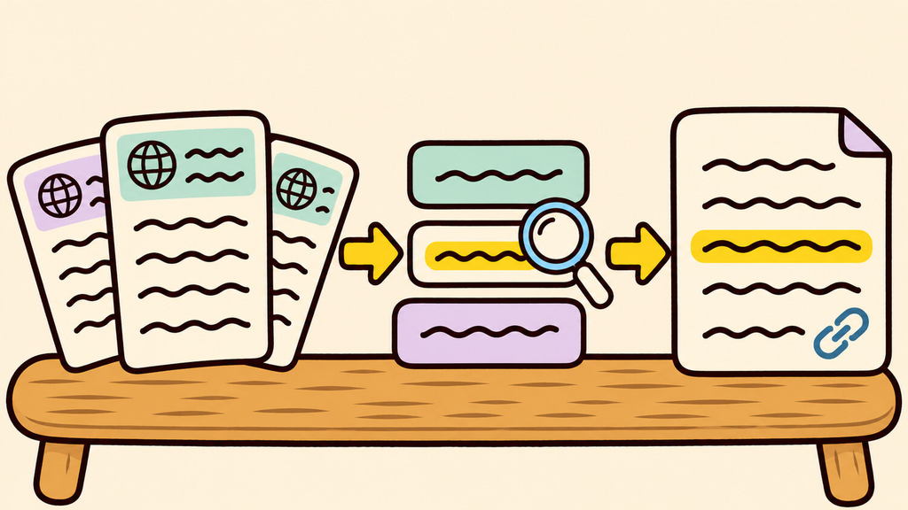

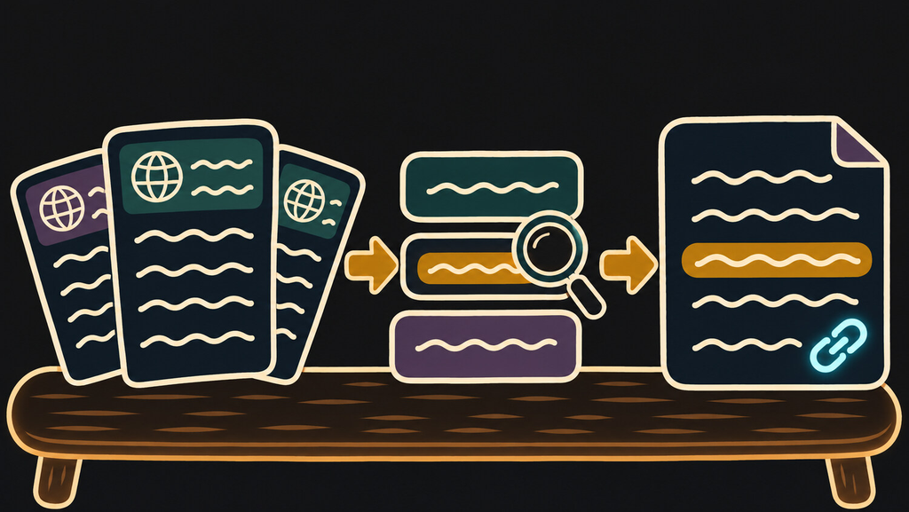

1. Extract nuggets
2. Write and cite

## Extract nuggets

**24** selected articles

→

**Nuggetizer**Extract claims across the set.  
Check each claim against all 24 articles.

→

**19** nuggets keptEach had full support

**11** distinct articles fully supported at least one retained nugget. The report cited **7** of those articles.

Two nuggets from the African penguin run

- Fishing ban aims to increase prey availability for penguins
- Penguin breeding pairs declined 77% in 30 years

## Nuggets guide the report

Topic 2014 · GPT-5.6 Sol

1. **Plan coverage**

   Use the request and 19 extracted nuggets.
2. **Allocate space**

   Use 4,900 characters. More fully supporting articles give a nugget more space.
3. **Write with citations**

   Use eligible articles for details. Map source labels to original article IDs.

2 supporting articles · 239 characters for this nugget

Fishing ban aims to increase prey availability for penguins

The nugget puts fishing restrictions on the writing plan. News24 supplies the 2008 study result.

## Check the report before submitting

1. **Validate citation labels**

   Require an eligible source label for each factual sentence.
2. **Allow one rewrite**

   Send validation errors back to the writer.
3. **Fit 5,000 characters**

   Keep whole sentences and resolve citations to original IDs.

## How AutoARGUE scored a cited sentence

News24 article · English original

> “Research carried out in 2008 found that restricted fishing around four breeding colonies slowed down … population decline from around **7% to 5% per year**.”

Submitted English report

> A 2008 experiment found that restricted fishing around four colonies slowed annual population decline from about **7% to 5%**.<sup>[1](https://github.com/npatta01/trec_ragtime_2026/blob/a4561cf097dcfaf249ddfc3dcf25845a897d187a/submissions/np-nugget-sol-v1/NP.np-nugget-sol-v1.ragtime26.jsonl#L15)</sup>

[1] News24 · `…_415417328` · [Submitted report](https://github.com/npatta01/trec_ragtime_2026/blob/a4561cf097dcfaf249ddfc3dcf25845a897d187a/submissions/np-nugget-sol-v1/NP.np-nugget-sol-v1.ragtime26.jsonl#L15) · Penguin results

**Citation support**

News24 supports the whole sentence.

**Nugget coverage**

**2008** answers “When was the study conducted?”

## Penguin topic results

Topic 2014 · Organizer reference articles

**13/13** retrieved

**10/13** selected

**7/13** cited

Submitted report · Preliminary AutoARGUE

**10/16** nuggets covered

**36/36** citations supported

### Examples AutoARGUE credited

- Breeding pairs fell by **77% over 30 years**.
- Conservation leaders named **food scarcity** as the main threat.
- South Africa extended fishing restrictions for **at least 10 years**.

Six details the report missed →

All 13 article matches · [Organizer nugget bank](https://github.com/npatta01/trec_ragtime_2026/blob/061c1b4de0ac6a982710ebeb2d5df350c4645c1b/results/2026-11-02/sources/nuggets_1101.tgz) · [Topic scores](https://github.com/npatta01/trec_ragtime_2026/blob/061c1b4de0ac6a982710ebeb2d5df350c4645c1b/results/2026-11-02/scores/repgen.autoargue.34-topics/np-nugget-sol-v1.scores.tsv#L122-L133)

## Six details the penguin report missed

**Selected articles contained all six details.** Five were in articles cited for other facts. All six were absent from the candidates Nuggetizer returned.

| Missing reference detail | Related text in our report | Selected article with the detail |
| --- | --- | --- |
| 9,900 breeding pairs worldwide | “about 20,000 today” (individual birds) | Daily Maverick · cited |
| 13,200 breeding pairs in 2019 | Breeding pairs “declined by 77% over 30 years” | News24 · cited |
| 97% decline over a century | From “as many as two million” a century ago to “about 20,000 today” | NBC Boston · cited |
| Bee swarm killed 63 penguins | 28 killed or culled in a separate bird-flu outbreak | Gazeta.ua and RFI Outside writer’s sources |
| Names of the targeted colonies Dassen Island, Robben Island, Stony Point, Dyer, Bird Island, St Croix | “six of the seven largest” colonies, without the names | News24 · cited |
| Fishing in less sensitive areas | **3 of 4 measures matched.** Fishing limits, government action and fish availability. | News24 · cited |

Penguin topic results · [Submitted report](https://github.com/npatta01/trec_ragtime_2026/blob/061c1b4de0ac6a982710ebeb2d5df350c4645c1b/submissions/np-nugget-sol-v1/NP.np-nugget-sol-v1.ragtime26.jsonl#L15) · Cited sentence

## Scores across topics

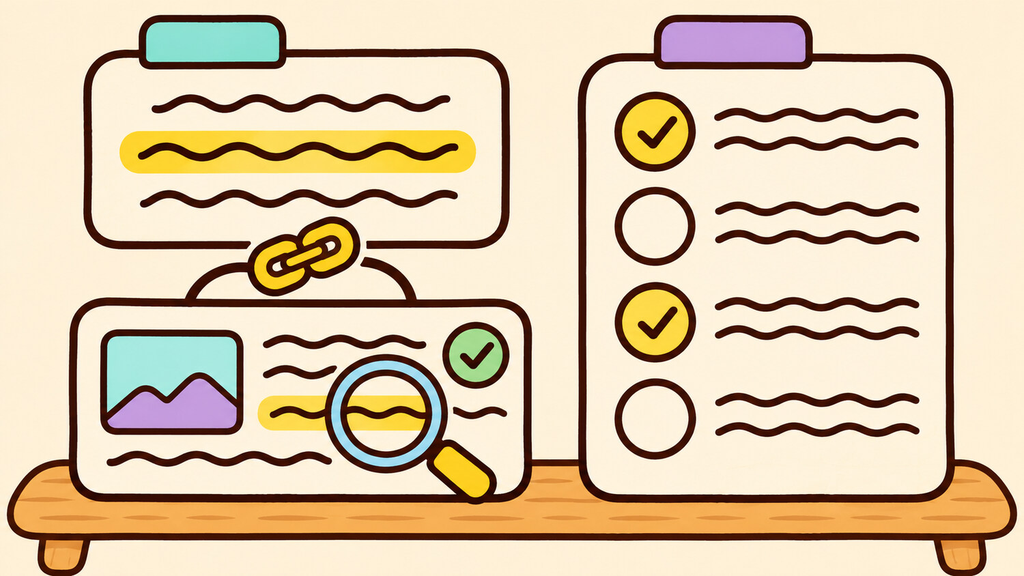

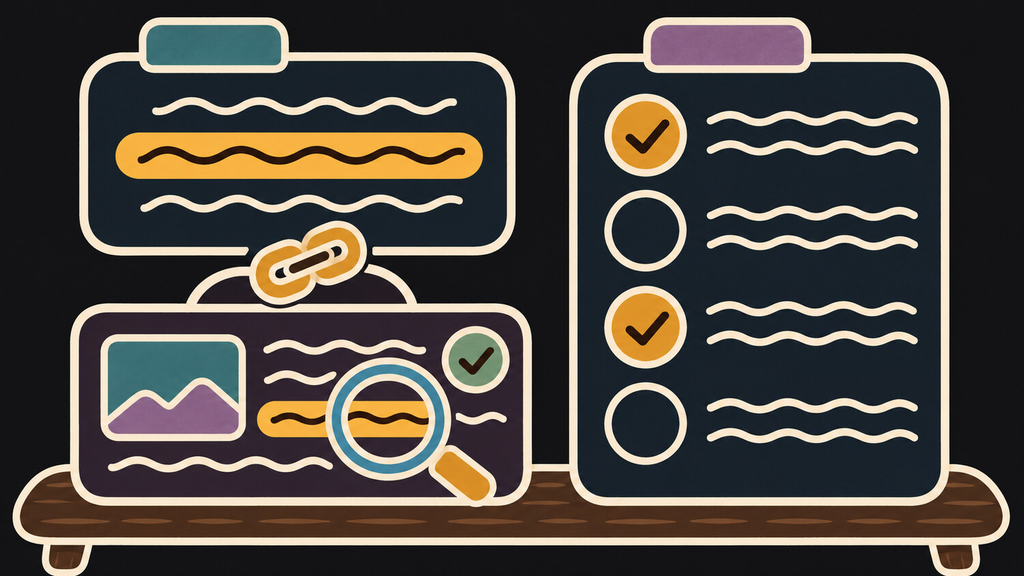

1. Citation support
2. Nugget coverage

## Citation support matched the highest score

Per citation · Did the article support the whole sentence? · 29 runs per evaluation

**One submission** · AutoARGUE (automated, 34 topics) · Mostly human (17-topic subset)

NP LabsField medianField max

### Mostly human 17 topics · llmfilled

**NP Labs 93.72%** Field median 81.55%

Max **93.72%**

### AutoARGUE 34 topics · micro

**NP Labs 95.73%** Field median 75.32%

Max **95.73%**

0%100%

Sentence support (all citations support their sentence) · **93.44%** mostly human · **95.81%** AutoARGUE

Mostly human · 687/700 citations human-judged. AutoARGUE · 1,324/1,383 citations supported.

## Nugget coverage beat the median

How many organizer reference nuggets appeared in supported sentences?

**One submission** · AutoARGUE (automated, 34 topics) · Mostly human (17-topic subset)

NP LabsField medianField max

### Mostly human 17 topics · llmfilled

**NP Labs 43.43%** Field median 35.81%

Max **47.63%**

### AutoARGUE 34 topics · micro

**NP Labs 39.16%** Field median 35.34%

Max **49.40%**

0%100%

AutoARGUE · **195 of 498** reference nuggets covered · Scores, including F1

## Conclusion

- Sent English queries to the organizers’ endpoint
- Reranked English originals and organizer-supplied translations
- Used nuggets to guide cited reports

**One submission.** Citation support matched the reported maximum and nugget coverage exceeded the median in both preliminary evaluations.

## Appendix

Queries, article matches, settings, scores and writing cost.

## All eight queries for Topic 2014

| Query | Search text |
| --- | --- |
| q₀ (broad rewrite) | African penguin population decline causes conservation measures South Africa international protection extinction risk |
| q₁ | African penguin population trends historical counts breeding pairs over years |
| q₂ | major threats to African penguin decline fishing oil spills climate change habitat loss |
| q₃ | African penguin extinction risk assessment IUCN status expert opinion |
| q₄ | South Africa African penguin conservation actions marine protected areas breeding sites |
| q₅ | international efforts to protect African penguin conservation programs organizations |
| q₆ | African penguin population numbers current estimates latest census data |
| q₇ | African penguin conservation measures government regulations fishing restrictions |

[Notebook paper, Table 1](https://github.com/npatta01/trec_ragtime_2026/blob/a4561cf097dcfaf249ddfc3dcf25845a897d187a/paper/ragtime2026-np-draft.tex#L126)

## Organizer reference article matches

Topic 2014 · 601 unique search hits · 24 articles selected for extraction

| Organizer article | Document ID suffix | Best search hit | Selected | Cited |
| --- | --- | --- | --- | --- |
| CBS News | `…_493999155` | q₀ · rank 4 | Yes | Yes |
| China Times | `…_483118047` | q₆ · rank 7 | Yes | Yes |
| Daily Maverick | `…_29057201` | q₀ · rank 1 | Yes | Yes |
| Gazeta.ua | `…_325848136` | q₆ · rank 17 | Yes | — |
| Gazeta.ua | `…_339284574` | q₆ · rank 18 | Yes | — |
| Hakai Magazine | `…_672465743` | q₂ · rank 2 | Yes | Yes |
| NBC Boston | `…_320019812` | q₆ · rank 4 | Yes | Yes |
| News24 | `…_415417328` | q₃ · rank 2 | Yes | Yes |
| RFI | `…_559172499` | q₆ · rank 6 | Yes | Yes |
| RFI | `…_854953281` | q₂ · rank 14 | Yes | — |
| China Times | `…_488800659` | q₆ · rank 26 | — | — |
| Echo of Moscow | `…_336318773` | q₆ · rank 73 | — | — |
| Minuto30 | `…_985288343` | q₆ · rank 22 | — | — |

Matches use full document IDs. Best rank is across the eight search lists. [Organizer nugget bank](https://github.com/npatta01/trec_ragtime_2026/blob/061c1b4de0ac6a982710ebeb2d5df350c4645c1b/results/2026-11-02/sources/nuggets_1101.tgz) · Penguin topic results

## Models and settings

| Stage | Setting |
| --- | --- |
| Query planning | deepseek-v4-flash-20260423 · broad rewrite + focused queries |
| Organizer search | Qwen3-Embedding-8B, FAISS and RoutIR · ragtime2%100 |
| English evidence | Original English text or supplied translation, joined by original document ID |
| Reranking | mxbai-rerank-base-v2 · all 100 hits per query for Topic 2014 |
| Claims | Round-robin cap 24 articles · Nuggetizer 0.0.5, cap 20 nuggets · MiniLM cosine ≥ 0.92 with number and negation checks |
| Writing | GPT-5.6 Sol through OpenRouter · temperature 0 · seed 7 · 4,000 max output tokens |
| Output | 4,900-character writing plan · hard limit 5,000 · three citations per sentence · one possible repair |

Unrecovered · full planner prompt, Nuggetizer LLM configuration, scorer input limits. [Notebook paper, models and settings](https://github.com/npatta01/trec_ragtime_2026/blob/a4561cf097dcfaf249ddfc3dcf25845a897d187a/paper/ragtime2026-np-draft.tex#L303)

## Preliminary score table

**One submission** · AutoARGUE (automated, 34 topics) · Mostly human (17-topic subset)

### Mostly human · 17 topics

| Metric | NP | Median | Max |
| --- | --- | --- | --- |
| Citation relevance | **0.7601** | 0.6491 | 0.7905 |
| Citation support | **0.9372** | 0.8155 | 0.9372 |
| Sentence support | **0.9344** | 0.7971 | 0.9344 |
| Nugget coverage | **0.4343** | 0.3581 | 0.4763 |
| F1 | **0.5715** | 0.4653 | 0.6093 |

### AutoARGUE · 34 topics

| Metric | NP | Median | Max |
| --- | --- | --- | --- |
| Citation relevance | **0.6905** | 0.6125 | 0.7381 |
| Citation support | **0.9573** | 0.7532 | 0.9573 |
| Sentence support | **0.9581** | 0.7550 | 0.9581 |
| Nugget coverage | **0.3916** | 0.3534 | 0.4940 |
| F1 | **0.5559** | 0.4436 | 0.6121 |

Organizer scores on a 0–1 scale. Mostly human uses llmfilled for support, coverage and F1. AutoARGUE uses micro. Medians and maxima summarize 29 runs.

[Organizer results and metric variants](https://github.com/npatta01/trec_ragtime_2026/blob/a4561cf097dcfaf249ddfc3dcf25845a897d187a/results/2026-11-02/README.md)

## What the writing pass cost

OpenRouter · GPT-5.6 Sol · 102 generated reports

**$20.19** recorded charges

About $0.20 per generated report

**115** attempts

102 drafts + 13 repair attempts

**50 s** median per report

Draft and any repair together

2.06M recorded writer tokens

- **1.70M** input
- **0.36M** output

**Nuggetizer cost** · Unverified from the saved run

Writer charges include earlier cached attempts. Total pipeline cost and elapsed time are unverified.

## When the writer abstains

Submitted run · 102 generated reports and 1 abstention

1. **Check support**

   Look for retained nuggets with a fully supporting article.
2. **Skip writing if none qualify**

   Return the insufficient-evidence response.

Submitted abstention response

> Insufficient citation-ready evidence was available to produce a supported report.

## Check for missing details before writing

Proposed change · Topic 2014 illustration

1. **Check coverage**

   Compare the requested aspects with the retained nuggets.
2. **Recheck selected articles**

   Extract any missing facts that those articles support.
3. **Search if needed**

   Run one focused query for a gap the selected articles do not address.

Example detail to check

Historical estimates of African penguin breeding pairs

Same writer and caps (24 articles, 20 nuggets, 5,000 chars). Compare coverage, citation support and calls.

Penguin coverage gaps · Appendix